# projet acp

Bennour Mohamed Aymen & Chalbi Achref

2022-02-05

La base de données {reponses} . Les données contiennent les preferences des series des individus c’est une base de 33 lignes et de 57 variables.

# Objectifs de l’ACP

l’objectif de cet acp est de classer les individus en des classes selon leurs preferences et leurs genres preferes de series. D’abord l’objectif est classer les individus a travers les preferences des series et finalement de les interpreter ces preferences a travers les variables qualitatives comme l’age et la categorie socioprofessionelle a travers une analyse des Correspondances Multiples.

# Importer et explorer le jeu de données et exprimer la matrices des series

```r
library("readxl")
reponses=read_excel("C:/users/user/Desktop/bennour/reponses.xlsx")
head(reponses)
```

| Horodateur | vous êtes un(e) ? | age | csp | ou habitez vous ? | netflix | si oui , qui paie pour ce compte ? | si non , sur internet , pour visionner des séries , vous : | combien de séries vous regardez par mois ? | drame | comédie | aventure | action | crime | horreur | psychologie | sci fiction & fantasy | historique | romantique | documentaires | que préférez vous ? | game of thrones | breaking bad | the walking dead | La casa de papel | friends | how i met your mother | sherlock | attack on titans | prison break | … |
| --- | --- | --- | --- | --- | --- | --- | --- | --- | --- | --- | --- | --- | --- | --- | --- | --- | --- | --- | --- | --- | --- | --- | --- | --- | --- | --- | --- | --- | --- | --- |
| 2022-03-24 10:55:48 | homme | entre 18 et 24 ans | étudiant(e) | grand tunis | non | 0 | les regarder sur une plateforme de streaming illégal | moins d'une | 4 | 4 | 4 | 4 | 4 | 4 | 4 | 3 | 3 | 4 | 3 | les mini séries | 4 | 4 | 4 | 4 | 2 | 2 | 2 | 4 | 4 | … |
| 2022-03-24 10:59:16 | homme | entre 18 et 24 ans | étudiant(e) | grand tunis | non | 0 | les regarder sur une plateforme de streaming illégal | moins d'une | 3 | 4 | 4 | 4 | 4 | 3 | 4 | 3 | 2 | 2 | 4 | 0 | 4 | 5 | 3 | 5 | 3 | 3 | 3 | 5 | 2 | … |
| 2022-03-24 11:00:00 | homme | entre 18 et 24 ans | étudiant(e) | grand tunis | oui | un(e) ami | les telecharger | entre 3 et 5 | 4 | 4 | 4 | 4 | 3 | 3 | 3 | 2 | 4 | 3 | 4 | les longs series | 5 | 5 | 2 | 1 | 2 | 2 | 2 | 5 | 4 | … |
| 2022-03-24 11:01:11 | femme | entre 18 et 24 ans | élève(e) | grand tunis | non | aucune idée | les telecharger | moins d'une | 5 | 5 | 2 | 2 | 5 | 1 | 5 | 1 | 4 | 5 | 4 | les longs series | 5 | 5 | 2 | 2 | 4 | 5 | 2 | 2 | 5 | … |
| 2022-03-24 11:06:33 | homme | entre 18 et 24 ans | étudiant(e) | grand tunis | non | 0 | les regarder sur une plateforme de streaming illégal | moins d'une | 4 | 5 | 4 | 4 | 4 | 1 | 3 | 3 | 4 | 3 | 5 | les longs series | 4 | 2 | 4 | 2 | 2 | 4 | 5 | 4 | 2 | … |
| 2022-03-24 11:07:31 | homme | entre 18 et 24 ans | étudiant(e) | autre | non | 0 | les regarder sur une plateforme de streaming illégal | entre 1 et 3 | 3 | 4 | 4 | 2 | 4 | 1 | 4 | 4 | 5 | 2 | 4 | les longs series | 3 | 5 | 3 | 2 | 2 | 5 | 3 | 4 | 3 | … |

```r
df=reponses[,22:35]

  #library(dplyr)
  #library(magrittr)
  #library(knitr)
  #library(ggplot2)
```

## 1. Pertinence de l’ACP

Le corrgram donné ci-dessous permet d’étudier les corrélations entre les variables quantitatives : il est clair qu’il existe des corrélations importantes entre des groupes de variables ce qui suggère la pertinence de cette ACP (par exemple: game of thrones et vikings et game of thrones et you ).

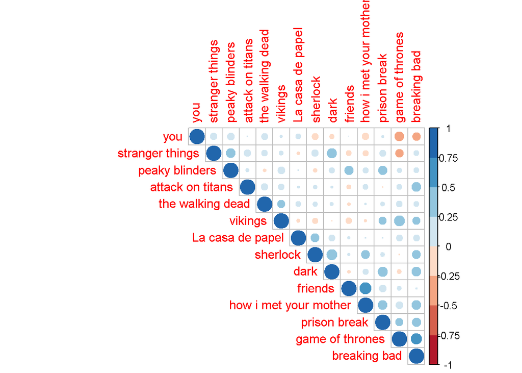

```r
library(corrplot)
X=as.matrix(reponses[,c(22:35)])
M<-cor(X)
library(RColorBrewer)
corrplot(M, type="upper", order="hclust",
         col=brewer.pal(n=8, name="RdBu"))
```